# hw6

**Q1**

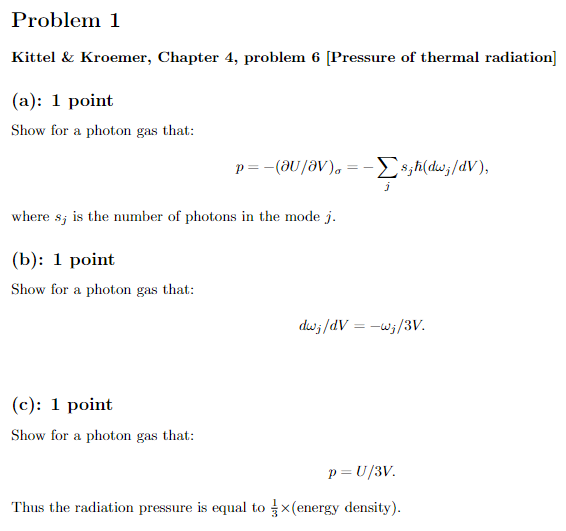

(a) A photon gas has energy

$$ U = \sum_j s_j \hbar \omega_j $$

Since entropy is held constant, the photons in $s_j$ will be constant as volume changes $ds/dV = 0$.

$$ p = - \frac{\partial}{\partial V} \sum_j s_j \hbar \omega_j = -\sum_j s_j \hbar \frac{\partial}{\partial V} \omega_j $$

(b) $\omega$ is related to the wave vector $k$, which must be a multiple of $n$ as discussed in the book. Using $\omega_j = c n_j \frac{\pi}{L}$ and $V = L^3$, we have

$$ \frac{d}{dV} \omega_j = c n_j \pi \frac{d}{dV} \frac{1}{L} \\ 1/L = 1/\sqrt[3]{V} \frac{d}{dV} \frac{1}{L} = \frac{1}{-3V^{4/3}} = \frac{1}{-3LV} \\ \frac{d}{dV} \omega_j = c n_j \pi\left( \frac{1}{L} \frac{-1}{3V} \right)= -\frac{\omega_j}{3V} $$

(c) Just plug in

$$ p = - \sum_j \frac{s_j \hbar \omega_j}{-3V} = \frac{U}{3V} $$

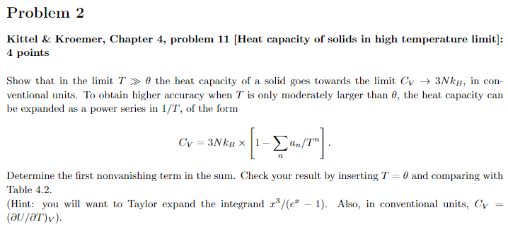

Taylor expansion:

$$ \frac{x^3}{e^x-1} \approx x^2-\frac{x^3}{2} + \frac{x^4}{12} - \dots $$

This should be all we need to get the result. Using (44) we have

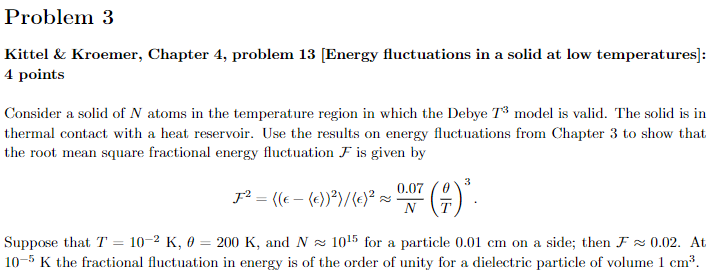

Using 3.89:

$$ \mathcal F^2 =\frac{\tau^2 \frac{\partial U }{\partial \tau}_V}{U^2} $$

At low temp $U$ scales with $\tau^4$ and $\frac{\partial U}{\partial \tau}_V=4U/\tau$ (think: $d \tau^4 = 4 \frac{\tau^4}{\tau}$)

This, alongside (46) from the book, gives us

$$ \mathcal F^2 = 4\tau/U \\ = \frac{20}{3\pi^4} \frac{1}{N} \left(\frac{k_B \theta}{\tau}\right) \approx \frac{0.07}{N} \left(\frac{\theta}{T}\right)^3 $$

If that in-between step looks familiar, I got it from an online solution rather than the book. Not sure how to do this otherwise.

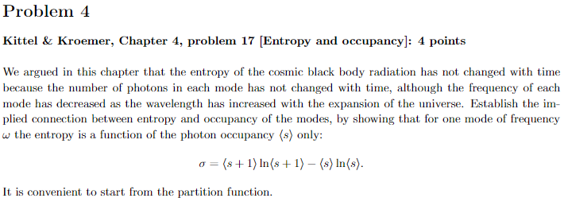

Ughghghn

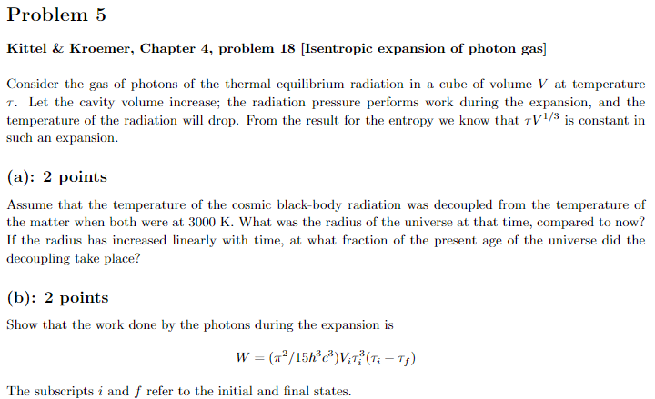

Assume a spherical cow universe of radius $r$

Constant $\tau V^{1/3} = \tau r$

(a) Avg temp now: $3K$

$$ \tau r = \tau r \\ r_i/r_f = 3/3000 = 10^{-3} \\ $$

The universe was much smaller than it is now (personally, I think it's still a reasonably large size), and it was 1/1000th the current age.

(b) $W = \Delta U$

Using (20) we have $U = \frac{\pi^2}{15 \hbar^3 c^3} V\tau^4$. Thus:

$$ W = \frac{\pi^2}{15 \hbar^3 c^3} \left(V_f \tau_f^4 - V_i\tau_i^4 \right) \\ V_i \tau_i^3 = V_f \tau_f^3 \\ W = \frac{\pi^2}{15 \hbar^3 c^3} \left(V_i \tau_i^3 \tau_f - V_i\tau_i^4\right) = \frac{\pi^2}{15 \hbar^3 c^3} V_i \tau_i^3 (\tau_i - \tau_f) $$